# STA 141A: Predicting Wildfire Incidence in the United States

## Abstract

This project investigates the prediction of wildfire occurrence using spatial and seasonal features derived from a wildfire dataset. Exploratory data analysis reveals strong geographic clustering of wildfires in the western United States as well as clear seasonal patterns in wildfire activity. Two classification models, logistic regression and random forest, are developed to predict wildfire occurrence using spatial location and cyclic month variables. Model performance is evaluated using a rolling time-based validation approach and measured using the Area Under the ROC Curve (AUC). The results show that the random forest model substantially outperforms the logistic regression model, demonstrating the benefit of flexible machine learning methods for wildfire prediction.

## Introduction

Wildfires pose significant environmental and economic challenges in many regions of the United States. Understanding patterns in wildfire occurrence and developing predictive models can help improve risk assessment and resource planning. In this report, we utilize a dataset of wildfire occurrences to develop these models. Our data comes from a subset that was derived from this Kaggle dataset: https://www.kaggle.com/datasets/rtatman/188-million-us-wildfires/data. We use spatial and seasonal features to build classification models that predict wildfire occurrence. This report has 5 sections, beginning with data preprocessing and ending with an overall summary. Analysis begins with exploratory data analysis to identify important patterns in the data, followed by the development and evaluation of predictive models.

### 1. Data Preprocessing

The raw wildfire dataset contains records of wildfire ignition locations, discovery dates, containment dates, and burned area across the United States.

Since the majority of fires are very small and quickly contained, we focus on *notable fires*. Following the project recommendation, we filter the dataset to retain only fires with a final burned area of at least 300 acres.

Temporal variables are then derived from the discovery date, including the month and year of each fire. These variables allow us to examine seasonal wildfire patterns and define the time units used in the prediction task. The resulting dataset contains notable fires along with the spatial and temporal variables used in the subsequent exploratory analysis and modeling steps.

```
##   OBJECTID FOD_ID     FPA_ID SOURCE_SYSTEM_TYPE SOURCE_SYSTEM
## 1      583    590 FS-1420201                FED   FS-FIRESTAT
## 2      590    597 FS-1420228                FED   FS-FIRESTAT
## 3      772    784 FS-1420566                FED   FS-FIRESTAT
## 4     3621   3639 FS-1426387                FED   FS-FIRESTAT
## 5     3635   3653 FS-1426406                FED   FS-FIRESTAT
## 6     4401   4423 FS-1427596                FED   FS-FIRESTAT
##   NWCG_REPORTING_AGENCY NWCG_REPORTING_UNIT_ID
## 1                    FS                USAZTNF
## 2                    FS                USAZTNF
## 3                    FS                USMTKNF
## 4                    FS                USIDNCF
## 5                    FS                USIDNCF
## 6                    FS                USIDBOF
##                  NWCG_REPORTING_UNIT_NAME SOURCE_REPORTING_UNIT
```

[output cut: 48 more lines]

```
##   total_fires avg_fire_size min_fire_size max_fire_size
## 1        1381       4921.37           300        344833
```

### 2. Exploratory Data Analysis

In this EDA, we will explore patterns in the wildfire dataset to better understand the spatial and seasonal characteristics of wildfire occurrence. The goal of this EDA is to identify important features and trends that may be useful for predicting wildfire events. In particular, we will look closely at seasonal patterns, geographic clustering, and trends over time.

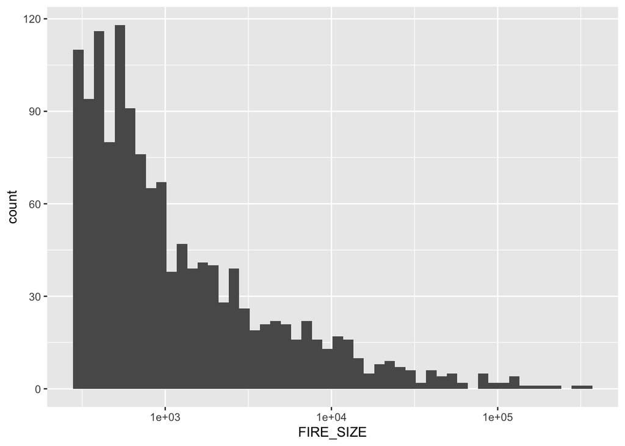

The distribution of wildfire sizes is heavily skewed to the right, with most fires being relatively small and a small number of extremely large fires. This shows that we should focus on notable fires when developing our predictive models.

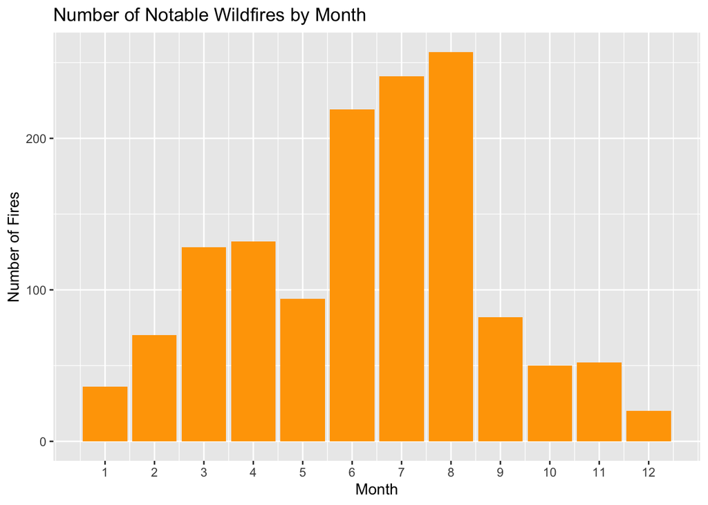

This bar graph shows the number of notable wildfires occurring in each month of the year. Wildfire activity increases substantially during the late spring and summer months, with the highest peaks occurring from June to August. This strong seasonal pattern suggests that wildfire risk varies throughout the year, which suggests that we should include cyclic month variables (month_sin and month_cos) as predictors in the models we build.

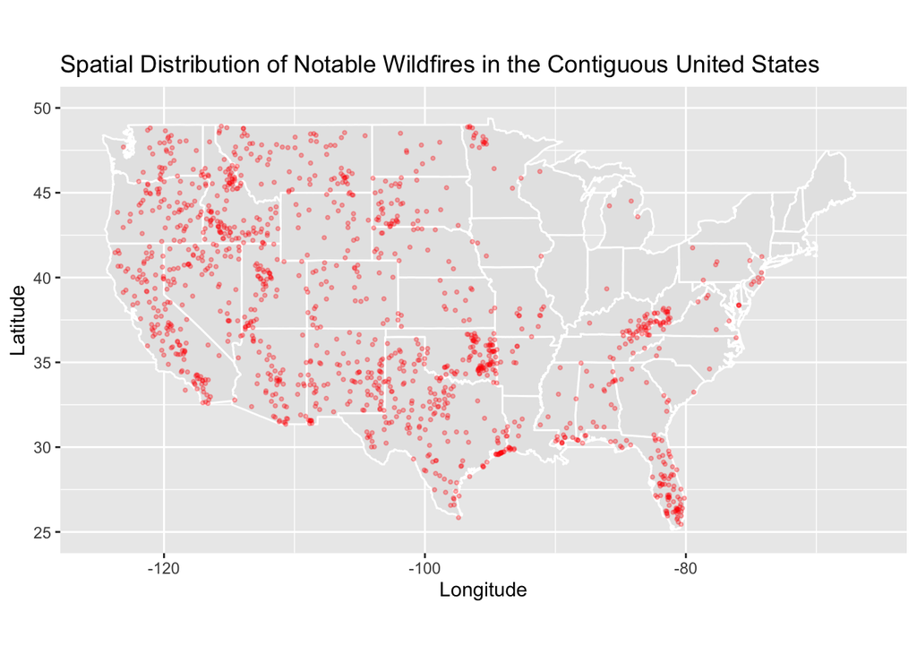

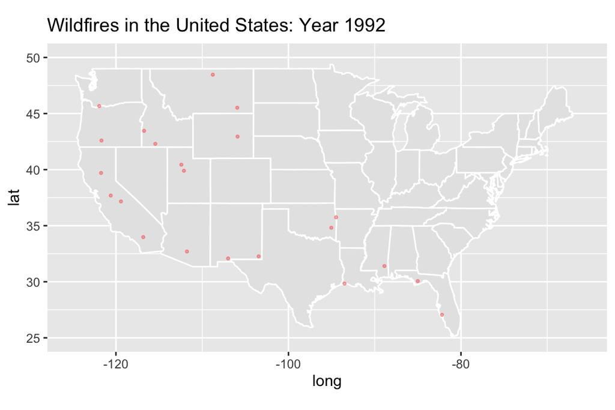

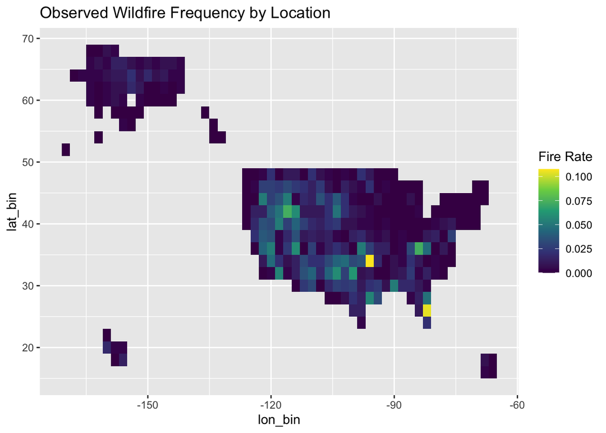

The overall spatial distribution map, the wildfires over time map, and the fire frequency heatmap all show that notable wildfires are concentrated primarily in the western United States, particularly in California, Idaho, and Utah, with some concentrations in the southeastern region of the US as well. These regions contain large forested areas and dry climates that are more prone to wildfire activity. This geographic clustering suggests that spatial variables such as latitude and longitude are also likely to be important predictors in the modeling stage. Including these variables allows the models to capture regional wildfire risk differences across the United States.

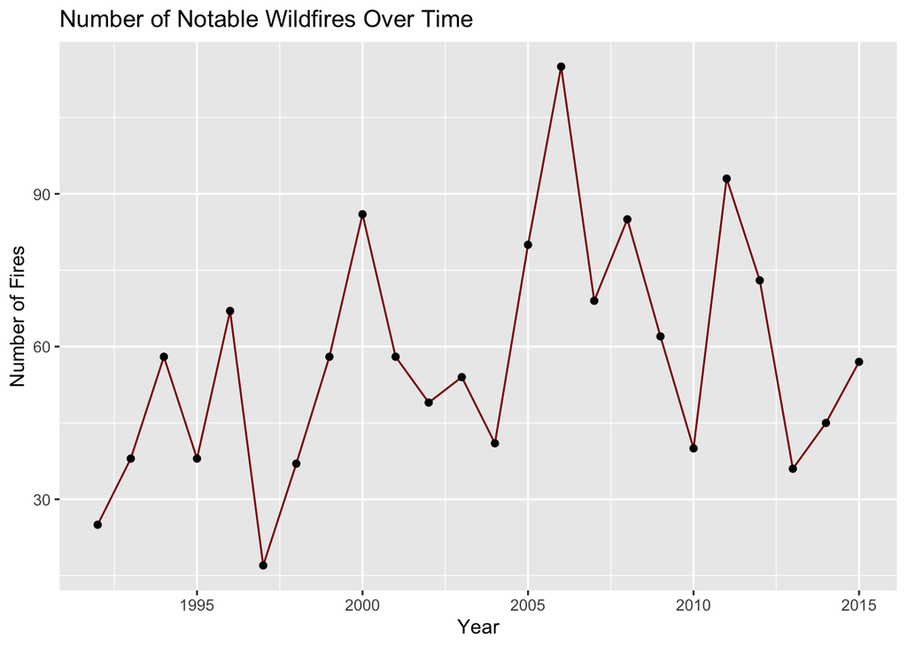

This time series plot shows the number of notable wildfires recorded each year. The number of fires fluctuates substantially from year to year, with several peaks during the mid-2000s. While there is some variability over time, the seasonal patterns observed earlier seem to be stronger drivers of wildfire occurrence.

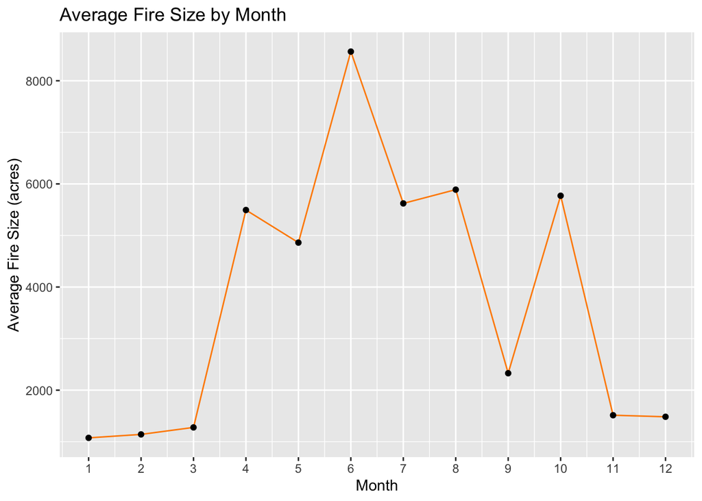

This plot shows how the average size of notable wildfires varies across months. Average fire size increases sharply during late spring and early summer, with the largest fires occurring around June. This pattern further supports the presence of strong seasonal wildfire dynamics, where environmental conditions during warmer months allow fires to grow larger.

### 3. Modeling

In this section, we will create two classification models to predict wildfire occurrence: a logistic regression model and a random forest model. These models use spatial variables (lat_bin, lon_bin) and cyclic seasonal variables (month_sin, month_cos) as predictors. This section focuses on specifying and fitting the models, and we will fit and test their predictive performance in the next section.

```
##
## Call:
## glm(formula = fire_occurrence ~ lat_bin + lon_bin + month_sin +
##     month_cos, family = "binomial", data = data_model)
##
## Coefficients:
##              Estimate Std. Error z value Pr(>|z|)
## (Intercept) -3.546342   0.141712 -25.025  < 2e-16 ***
## lat_bin     -0.040275   0.002856 -14.102  < 2e-16 ***
## lon_bin     -0.005836   0.001256  -4.648 3.35e-06 ***
## month_sin   -0.219760   0.042884  -5.124 2.98e-07 ***
## month_cos   -0.873144   0.046521 -18.769  < 2e-16 ***
## ---
## Signif. codes:  0 '***' 0.001 '**' 0.01 '*' 0.05 '.' 0.1 ' ' 1
##
## (Dispersion parameter for binomial family taken to be 1)
##
##     Null deviance: 13109  on 95903  degrees of freedom
## Residual deviance: 12492  on 95899  degrees of freedom
## AIC: 12502
##
## Number of Fisher Scoring iterations: 8
```

We first implement a logistic regression model as the baseline model. Logistic regression is a simple and interpretable classification model that estimates the probability of wildfire occurrence as a function of geographic (lat_bin, lon_bin) and seasonal (month_sin, month_cos) predictors. This model gives us a benchmark against which we can test a more flexible machine learning model.

```
##
## Call:
##  randomForest(formula = as.factor(fire_occurrence) ~ lat_bin +      lon_bin + month_sin + month_cos, data = data_model, ntree = 300,      sampsize = rep(min(table(data_model$fire_occurrence)), 2))
##                Type of random forest: classification
##                      Number of trees: 300
## No. of variables tried at each split: 2
##
##         OOB estimate of  error rate: 22.95%
## Confusion matrix:
##       0     1 class.error
## 0 72907 21773   0.2299641
## 1   238   986   0.1944444
```

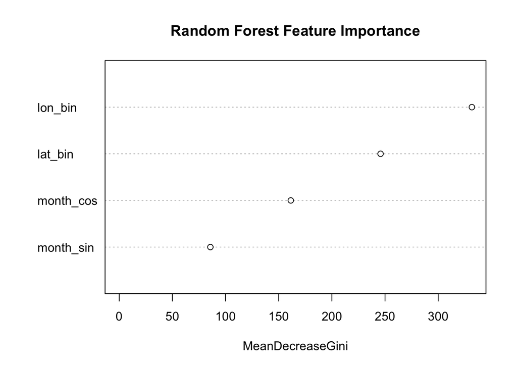

We next create a random forest classifier using the same predictors we used for the logistic regression model. Random forests combine many decision trees to capture nonlinear relationships and interactions between variables, so they have more complex methods than logistic regression models and can accommodate much more. The feature importance plot shows that latitude and longitude are the most influential predictors, while the seasonal variables also contribute to prediction. The strong importance of longitude and latitude could suggest that wildfire occurrence is influenced by geographic location, which shows differences in climate, vegetation, and land use across regions.

The models here are fit using the available dataset to show the model structure and predictors used for wildfire classification. This lets us examine model behavior and feature importance, but they do not represent a formal evaluation of predictive performance. In the next section, we will fit the models again using a rolling time-based validation approach so that predictions can be evaluated on data that was not used during training.

### 4. Model Fitting and Validation

Now, we will fit and evaluate both models. We will use a rolling time-based method to evaluate them both. For each year, the models will be trained on data from every year before so that they can be tested on that year. This approach makes sure that predictions are evaluated on out-of-sample data and more closely reflects how the models would perform in practice. We are using the AUC values of both models to evaluate them.

```
##  [1] 1992 1993 1994 1995 1996 1997 1998 1999 2000 2001 2002 2003 2004 2005 2006
## [16] 2007 2008 2009 2010 2011 2012 2013 2014 2015
```

```
## [1] 24
```

```
## # A tibble: 21 × 4
##    train_end_year test_year auc_glm auc_rf
##             <dbl>     <dbl>   <dbl>  <dbl>
##  1           1994      1995   0.710  0.831
##  2           1995      1996   0.699  0.889
##  3           1996      1997   0.820  0.892
##  4           1997      1998   0.811  0.883
##  5           1998      1999   0.685  0.796
##  6           1999      2000   0.652  0.838
##  7           2000      2001   0.698  0.852
##  8           2001      2002   0.695  0.853
##  9           2002      2003   0.752  0.857
## 10           2003      2004   0.670  0.836
## # ℹ 11 more rows
```

To evaluate predictive performance, we use rolling time-based validation procedure. For each year, the models are trained on all data from previous years and then tested on the following year. This approach mimics a real-world prediction setting, where future wildfire occurrences must be predicted using only past information. The procedure produces predicted probabilities for wildfire occurrence in the test year, which are then used to compute model performance metrics such as AUC. From the results, we can see that the logistic regression model’s AUC mostly hovers around the 0.7 area, while the random forest model’s AUC is consistently in the 0.8’s, so it is significantly outdoing the logistic regression model.

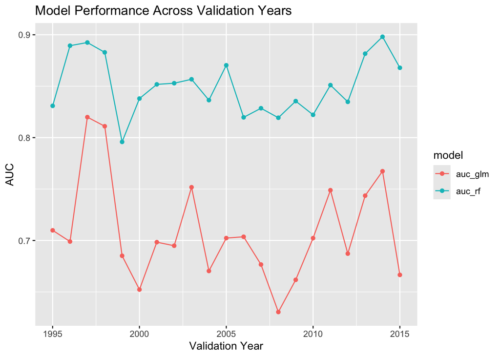

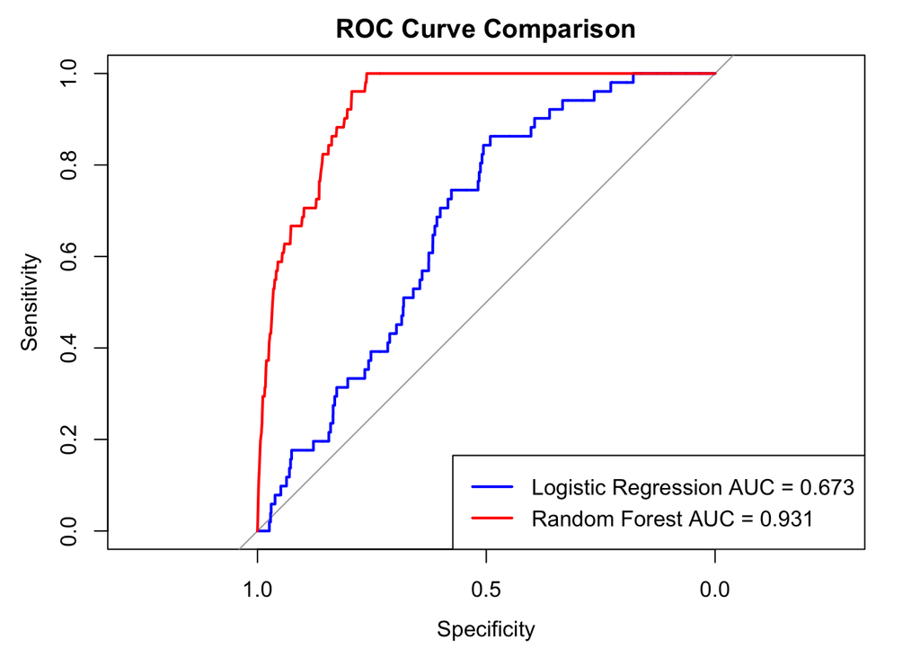

Overall, these results show that incorporating nonlinear machine learning methods such as random forests can significantly improve wildfire prediction relative to traditional linear models.

### 5. Summary

In this project, we developed predictive models to classify notable wildfire occurrences in the United States using spatial and seasonal predictors derived from wildfire records. The exploratory data analysis revealed strong seasonal and geographic patterns in wildfire activity. The number of fires increases substantially during the late spring and summer months, and the average fire size also peaks during this period, with the largest fires occurring around June. Spatial visualizations further showed that wildfires are heavily concentrated in the western United States, suggesting that both geographic location and seasonal climate conditions play an important role in wildfire risk.

We used two predictive models to classify wildfire occurrence: a baseline logistic regression model and a more flexible random forest classifier. Logistic regression provided an interpretable statistical model that estimates wildfire probability as a function of latitude, longitude, and cyclic seasonal variables. The random forest model extended this by capturing nonlinear relationships and interactions between predictors through an ensemble of decision trees. Feature importance results from the random forest model indicate that geographic variables (longitude and latitude) are the most influential predictors, while seasonal predictors also contribute meaningfully to wildfire prediction.

Overall, the analysis demonstrates that incorporating nonlinear machine learning methods can substantially improve predictive performance for wildfire classification. Future improvements could include incorporating additional environmental predictors such as temperature, precipitation, vegetation, and wind conditions, as well as using finer spatial resolution data. Also, we could use a more advanced model such as a neural network to get more accurate results. Such enhancements could further improve our ability to identify regions at high risk of wildfire occurrence.

### Code

```r
knitr::opts_chunk$set(
  echo = FALSE,
  message = FALSE,
  warning = FALSE
)

# Section 1 Code

library(tidyverse)

fires <- read.csv("/Users/bharathramsridhar/Downloads/wildfires_sample_100k.csv")
fires$DISCOVERY_DATE <- as.Date(fires$DISCOVERY_DATE - 2440587.5, origin = "1970-01-01")
fires$year <- as.numeric(substr(fires$DISCOVERY_DATE, 1, 4))
fires$month <- as.numeric(substr(fires$DISCOVERY_DATE, 6, 7))

fires_clean <- fires %>%
  filter(FIRE_SIZE >= 300) %>%
  mutate(
    lat_bin = floor(LATITUDE / 2) * 2,
    lon_bin = floor(LONGITUDE / 2) * 2,
    month = as.numeric(format(DISCOVERY_DATE, "%m")),
    year  = as.numeric(format(DISCOVERY_DATE, "%Y"))
  )

fires_clean$lat_bin <- floor(fires_clean$LATITUDE / 2) * 2
fires_clean$lon_bin <- floor(fires_clean$LONGITUDE / 2) * 2
fires_clean$year  <- as.numeric(format(fires_clean$DISCOVERY_DATE, "%Y"))

fire_counts <- fires_clean %>%
  group_by(lat_bin, lon_bin, year, month) %>%
  summarise(fire_count = n(), .groups = "drop")
fire_counts$month <- as.numeric(fire_counts$month)

locations <- fires %>%
  mutate(
    lat_bin = floor(LATITUDE / 2) * 2,
    lon_bin = floor(LONGITUDE / 2) * 2
  ) %>%
  distinct(lat_bin, lon_bin)

grid <- locations %>%
  crossing(
    year = unique(fires_clean$year),
    month = 1:12
  )

data_model <- left_join(grid, fire_counts,
                        by=c("lat_bin","lon_bin","year","month"))

data_model$fire_count[is.na(data_model$fire_count)] <- 0
data_model$fire_occurrence <- ifelse(data_model$fire_count>0,1,0)

head(fires_clean)

fires_clean %>%
  summarise(
    total_fires = n(),
    avg_fire_size = mean(FIRE_SIZE, na.rm = TRUE),
    min_fire_size = min(FIRE_SIZE, na.rm = TRUE),
    max_fire_size = max(FIRE_SIZE, na.rm = TRUE)
  )

#Section 2 Code

ggplot(fires_clean, aes(FIRE_SIZE)) +
  geom_histogram(bins=50) +
  scale_x_log10()

ggplot(fires_clean, aes(x = month)) +
  geom_bar(fill = "orange") +
  scale_x_continuous(breaks = 1:12) +
  labs(
    title = "Number of Notable Wildfires by Month",
    x = "Month",
    y = "Number of Fires"
  )

library(maps)

fires_map <- fires_clean %>%
  filter(LATITUDE >= 25 & LATITUDE <= 50,
         LONGITUDE >= -125 & LONGITUDE <= -66)

us_map <- map_data("state")

ggplot() +
  geom_polygon(data = us_map,
               aes(x = long, y = lat, group = group),
               fill = "gray90",
               color = "white") +
  geom_point(data = fires_map,
             aes(x = LONGITUDE, y = LATITUDE),
             color = "red",
             alpha = 0.3,
             size = 0.7) +
  coord_fixed(1.3, xlim = c(-125, -66), ylim = c(25, 50)) +
  labs(
    title = "Spatial Distribution of Notable Wildfires in the Contiguous United States",
    x = "Longitude",
    y = "Latitude"
  )

library(gganimate)

p <- ggplot() +
  geom_polygon(data = us_map,
               aes(x = long, y = lat, group = group),
               fill = "gray90",
               color = "white") +
  geom_point(data = fires_map,
             aes(x = LONGITUDE, y = LATITUDE),
             color = "red",
             alpha = 0.3,
             size = 0.7) +
  coord_fixed(1.3, xlim = c(-125, -66), ylim = c(25, 50)) +
  labs(title = "Wildfires in the United States: Year {round(frame_time)}") +
  transition_time(year)

animate(p, nframes = 80, fps = 8)
data_model %>%
  group_by(lat_bin, lon_bin) %>%
  summarise(fire_rate = mean(fire_occurrence)) %>%
  ggplot(aes(lon_bin, lat_bin, fill = fire_rate)) +
  geom_tile() +
  scale_fill_viridis_c() +
  labs(
    title="Observed Wildfire Frequency by Location",
    fill="Fire Rate"
  )

fires_clean %>%
  group_by(year) %>%
  summarise(fires = n()) %>%
  ggplot(aes(x = year, y = fires, group = 1)) +
  geom_line(color="darkred") +
  geom_point() +
  labs(
    title="Number of Notable Wildfires Over Time",
    x="Year",
    y="Number of Fires"
  )

fires_clean %>%
  group_by(month) %>%
  summarise(avg_fire_size = mean(FIRE_SIZE, na.rm = TRUE)) %>%
  ggplot(aes(x = month, y = avg_fire_size)) +
  geom_line(color = "darkorange") +
  geom_point() +
  scale_x_continuous(breaks = 1:12) +
  labs(
    title = "Average Fire Size by Month",
    x = "Month",
    y = "Average Fire Size (acres)"
  )

# Section 3 Code

data_model <- data_model %>%
  mutate(
    month_sin = sin(2 * pi * month / 12),
    month_cos = cos(2 * pi * month / 12)
  )

log_model <- glm(
  fire_occurrence ~ lat_bin + lon_bin + month_sin + month_cos,
  data = data_model,
  family = "binomial"
)

summary(log_model)

library(randomForest)

rf_model <- randomForest(
  as.factor(fire_occurrence) ~ lat_bin + lon_bin + month_sin + month_cos,
  data = data_model,
  ntree = 300,
  sampsize = rep(min(table(data_model$fire_occurrence)), 2)
)

rf_model

varImpPlot(rf_model,
           main = "Random Forest Feature Importance")

# Section 4 Code

library(purrr)
library(pROC)

years_sorted <- sort(unique(data_model$year))
years_sorted
length(years_sorted)
min_train_years <- 3

results <- tibble(
  train_end_year = years_sorted[min_train_years:(length(years_sorted)-1)],
  test_year = years_sorted[(min_train_years+1):length(years_sorted)]
)

results <- results %>%
  mutate(

    auc_glm = map2_dbl(train_end_year, test_year, function(tr_end, te_year){

      train <- filter(data_model, year <= tr_end)
      test  <- filter(data_model, year == te_year)

      fit <- glm(
        fire_occurrence ~ lat_bin + lon_bin + month_sin + month_cos,
        data = train,
        family = "binomial"
      )

      probs <- predict(fit, newdata = test, type = "response")

      as.numeric(roc(test$fire_occurrence, probs, quiet = TRUE)$auc)
    }),

    auc_rf = map2_dbl(train_end_year, test_year, function(tr_end, te_year){

      train <- filter(data_model, year <= tr_end)
      test  <- filter(data_model, year == te_year)

      rf_fit <- randomForest(
        as.factor(fire_occurrence) ~ lat_bin + lon_bin + month_sin + month_cos,
        data = train,
        ntree = 200,
        sampsize = rep(min(table(train$fire_occurrence)), 2)
      )

      probs <- predict(rf_fit, newdata = test, type = "prob")[,2]

      as.numeric(roc(test$fire_occurrence, probs, quiet = TRUE)$auc)
    })

  )

results

library(ggplot2)

results %>%
  pivot_longer(cols = c(auc_glm, auc_rf),
               names_to = "model",
               values_to = "AUC") %>%
  ggplot(aes(x = test_year, y = AUC, color = model)) +
  geom_line() +
  geom_point() +
  labs(
    title = "Model Performance Across Validation Years",
    x = "Validation Year",
    y = "AUC"
  )

train_end <- max(results$train_end_year)
test_year <- max(results$test_year)

train <- dplyr::filter(data_model, year <= train_end)
test  <- dplyr::filter(data_model, year == test_year)

glm_probs <- predict(log_model, newdata = test, type = "response")

rf_probs <- predict(rf_model, newdata = test, type = "prob")[,2]

roc_glm <- roc(test$fire_occurrence, glm_probs)
roc_rf  <- roc(test$fire_occurrence, rf_probs)

plot(roc_glm,
     col = "blue",
     lwd = 2,
     main = "ROC Curve Comparison")

plot(roc_rf,
     col = "red",
     lwd = 2,
     add = TRUE)

legend("bottomright",
       legend = c(
         paste("Logistic Regression AUC =", round(auc(roc_glm),3)),
         paste("Random Forest AUC =", round(auc(roc_rf),3))
       ),
       col = c("blue","red"),
       lwd = 2)
```